# STATS 769 Lab04

Xuan Fang

8/28/2020

# Task 1

```r
library(jsonlite)
```

The following code reads the JSON file into R.

```r
## Read JSON file into R
## fromJSON() function converts JSON data to R objects
temp <- fromJSON(readLines("/course/COVID/JSON/owid-covid-data.json"))
## The temp is list and has lists within (the nested list).
class(temp)
```

```
## [1] "list"
```

```r
length(temp)
```

```
## [1] 211
```

## Commentary:

The JSON file contains information for 211 locations (the last one is for the entire World), including numbers of cases of COVID per day (from the start of the year). We are interested in the relationship between the stringency of measures (against COVID) and the number of cases per day. Thus, we need to extract `new_cases_per_million` and `stringency_index` data from the JSON file.

There are 211 records in total, but the last one is the record for the entire World (we need to remove OWID_WRL). I found that not all countries have both `new_cases_per_million` and `stringency_index`. Thus, we need records that have both variables in it (i.e., need to remove non-paired ones).

```r
new_cases_per_million <- numeric(0)
stringency_index <- numeric(0)


for (i in 1:(length(temp)-1)){ ## only keep the paired ones
  if(length(temp[[i]]$data$new_cases_per_million) == length(temp[[i]]$data$stringency_index)){
  new_cases_per_million <- c(new_cases_per_million, temp[[i]]$data$new_cases_per_million)
  stringency_index <- c(stringency_index, temp[[i]]$data$stringency_index)
  }
}

## Create a data frame
cases <- data.frame(new_cases_per_million, stringency_index)
```

```r
## Have a look at the dimension of the data frame
dim(cases)
```

```
## [1] 32927     2
```

# Task 2

```r
library(mongolite)
```

The file “COVID” contained in the MongoDB database (A document-oriented database based on JSON documents). The following code reads the file into R.

```r
## Connect via m <- mongo(...)
m <- mongo("COVID")
## We use queries via a find operation that uses documents to specify selections:
## 1) Need to extract the two variables of interest from the databases;
## 2) Need to exclude the World record.
temp2 <- m$find(query='{"location": {"$ne": "World"}}', fields='{"data.new_cases_per_million": 1, "data.stringency_index": 1, "_id": 0}')
```

```r
## I found that not all countries have both `new_cases_per_million` and `stringency_index`
## Thus, we need records which have both variables in it (i.e. need to remove non-paired ones)
new_cases_per_million <- numeric(0)
stringency_index <- numeric(0)

for (i in 1:(dim(temp2)[1])){ ## only keep the paired ones
    if(length(data.frame(temp2[i,1])$new_cases_per_million) == length(data.frame(temp2[i,1])$stringency_index)){
      new_cases_per_million <- c(new_cases_per_million, data.frame(temp2[i,1])$new_cases_per_million)
      stringency_index <- c(stringency_index, data.frame(temp2[i,1])$stringency_index)
    }
}

## Create a data frame
cases.2 <- data.frame(new_cases_per_million, stringency_index)
```

A simple demonstration:

```r
## Have a look at the dimension of the data frame
dim(cases)
```

```
## [1] 32927     2
```

```r
dim(cases.2)
```

```
## [1] 32927     2
```

```r
## The first 6 observations:
head(cases)
```

```
##   new_cases_per_million stringency_index
## 1                18.733             0.00
## 2                    NA            33.33
## 3                18.733            33.33
## 4                    NA            44.44
## 5                    NA            44.44
## 6                    NA            44.44
```

```r
head(cases.2)
```

```
##   new_cases_per_million stringency_index
## 1                18.733             0.00
## 2                    NA            33.33
## 3                18.733            33.33
## 4                    NA            44.44
## 5                    NA            44.44
## 6                    NA            44.44
```

```r
## The last 6 observations:
tail(cases)
```

```
##       new_cases_per_million stringency_index
## 32922                 6.526               NA
## 32923                 5.517               NA
## 32924                 6.997               NA
## 32925                 5.719               NA
## 32926                 3.162               NA
## 32927                 4.710               NA
```

```r
tail(cases.2)
```

```
##       new_cases_per_million stringency_index
## 32922                 6.526               NA
## 32923                 5.517               NA
## 32924                 6.997               NA
## 32925                 5.719               NA
## 32926                 3.162               NA
## 32927                 4.710               NA
```

# Task 3

```r
library(xml2)
```

Have a look at the structure:

```r
cat(readLines("/course/COVID/XML/covid.xml", n=20), sep="\n")
```

```
## <?xml version="1.0" encoding="UTF-8"?>
## <records>
##  <record>
##      <dateRep>19/08/2020</dateRep>
##      <day>19</day>
##      <month>08</month>
##      <year>2020</year>
##      <cases>0</cases>
##      <deaths>0</deaths>
##      <countriesAndTerritories>Afghanistan</countriesAndTerritories>
##      <geoId>AF</geoId>
##      <countryterritoryCode>AFG</countryterritoryCode>
##      <popData2019>38041757</popData2019>
##      <continentExp>Asia</continentExp>
##      <Cumulative_number_for_14_days_of_COVID-19_cases_per_100000>2.02409158</Cumulative_number_for_14_days_of_COVID-19_cases_per_100000>
##  </record>
##  <record>
##      <dateRep>18/08/2020</dateRep>
##      <day>18</day>
##      <month>08</month>
```

Read the XML file into R:

```r
temp3 <- read_xml("/course/COVID/XML/covid.xml")
## The result is NOT a data frame.
class(temp3)
```

```
## [1] "xml_document" "xml_node"
```

Extract the date and the number of cases for Afghanistan from the XML file:

```r
## Extract elements of interest using xml_find_all() and XPath expressions
record <- xml_find_all(temp3, "//record[countriesAndTerritories/text()='Afghanistan']")
date <- xml_text(xml_find_all(record,".//dateRep/text()"))
cases_af <- xml_text(xml_find_all(record,".//cases/text()"))

## Combine the 2 variables into a single data frame.
AF.df <- data.frame(date, cases_af)

## Specify the variables as the appropriate class.
AF.df$date <- as.Date(AF.df$date, format = "%d/%m/%Y")
AF.df$cases <- as.numeric(AF.df$cases_af)
```

Extract the date and the number of cases for Afghanistan in JSON file:

```r
for (i in 1:210){
  if (temp[[i]]$location=="Afghanistan") {
  date2 <- temp[[i]]$data$date
  cases2 <- temp[[i]]$data$new_cases
  }
}

## Combine the 2 variables into a single data frame.
AF.df2 <- data.frame(date = date2, cases = as.numeric(cases2))
## Specify the variables as the appropriate class.
AF.df2$date <- as.Date(AF.df2$date, format = "%Y-%m-%d")
```

The plot:

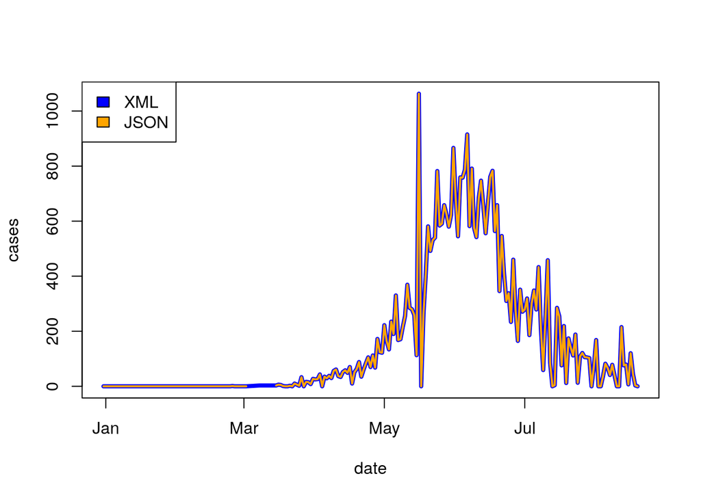

```r
plot(cases~date, data=AF.df, type = "l", col = "blue", lwd = 4)
lines(cases~date, data=AF.df2, type = "l", col = "orange", lwd = 2)
legend("topleft", c("XML","JSON"), fill=c("blue","orange"))
```

## Commentary:

The two lines are overlapped except there were some missing data in March from the JSON file.

# Task 4

```r
summary(cases$new_cases_per_million)
```

```
##     Min.  1st Qu.   Median     Mean  3rd Qu.     Max.     NA's
## -265.189    0.000    1.372   19.549   12.973 1892.582      458
```

```r
head(table(cases$new_cases_per_million), 20)
```

```
##
## -265.189 -139.488  -83.886   -38.57   -17.24  -15.789   -15.25  -11.735
##        1        1        1        1        1        1        1        1
##  -10.781   -7.956   -2.834   -2.514   -2.448   -0.022        0    0.001
##        1        1        1        1        1        1    10159       19
##    0.002    0.003    0.004    0.005
##        8       19        5       15
```

```r
sum(cases$new_cases_per_million < 0, na.rm = TRUE)
```

```
## [1] 14
```

## Commentary:

There are $14$ negative values in `new_cases_per_million`. Also, there are $458$ missing values (NA).

The number of negative values accounts for a small fraction of the data and would not harm our analysis if we drop them. Thus we choose only to keep those positive numbers of cases:

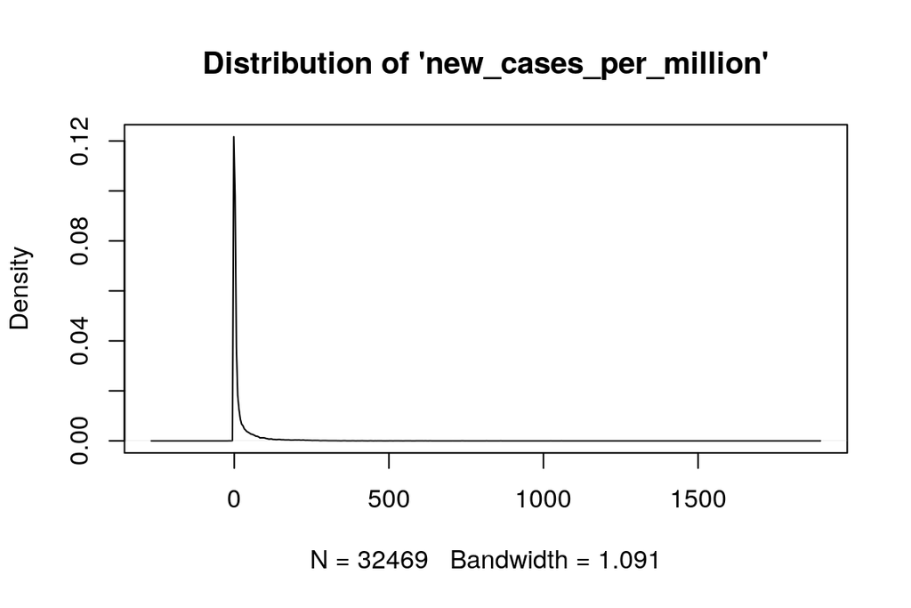

```r
plot(density(cases$new_cases_per_million, na.rm = TRUE), main="Distribution of 'new_cases_per_million'")
```

## Commentary:

A plot of the `new_cases_per_million` distribution looks very skewed. Thus we consider to transform it by using squra root transformation or log transformation.

```r
##cases$sqrtNCPM <- sqrt(cases$new_cases_per_million)
## plot(density(cases$sqrtNCPM, na.rm = TRUE), main="Distribution of 'sqrt(new_cases_per_million)'")
```

## Commentary:

Note that there are $10159$ zero values. We need to make them NA if we use log transformation. One reason for caution is that we throw out about $1/3$ of our data, so our estimate of the zero cases would be less reliable.

```r
sum(cases$new_cases_per_million == 0, na.rm = TRUE)
```

```
## [1] 10159
```

```r
cases$log_cases <- log(cases$new_cases_per_million)
```

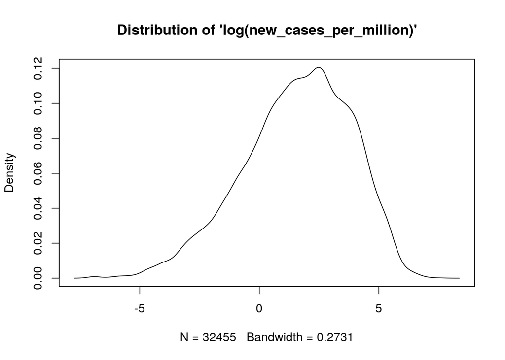

```r
cases$log_cases[!is.finite(cases$log_cases)] <- NA
plot(density(log(cases$new_cases_per_million), na.rm = TRUE), main="Distribution of 'log(new_cases_per_million)'")
```

## Commentary:

Now, it looks OKay.

## Task 5

data preparation

```r
## Have a look at the summary of the data frame:
summary(cases)
```

```
##  new_cases_per_million stringency_index   log_cases
##  Min.   :-265.189      Min.   :  0.00   Min.   :-6.908
##  1st Qu.:   0.000      1st Qu.: 38.89   1st Qu.: 0.144
##  Median :   1.372      Median : 65.74   Median : 1.776
##  Mean   :  19.549      Mean   : 58.13   Mean   : 1.582
##  3rd Qu.:  12.973      3rd Qu.: 80.56   3rd Qu.: 3.274
##  Max.   :1892.582      Max.   :100.00   Max.   : 7.546
##  NA's   :458           NA's   :1459     NA's   :10631
```

```r
## Exclude the missing values (NA)
df <- na.omit(cases)
dim(df)
```

```
## [1] 21366     3
```

```r
N <- nrow(df)
```

There is an increasing trend between the log of new cases per million and the stringency index, but after the index hit 60, the number of new cases seems to be flattened out (the rate of increase slows down).

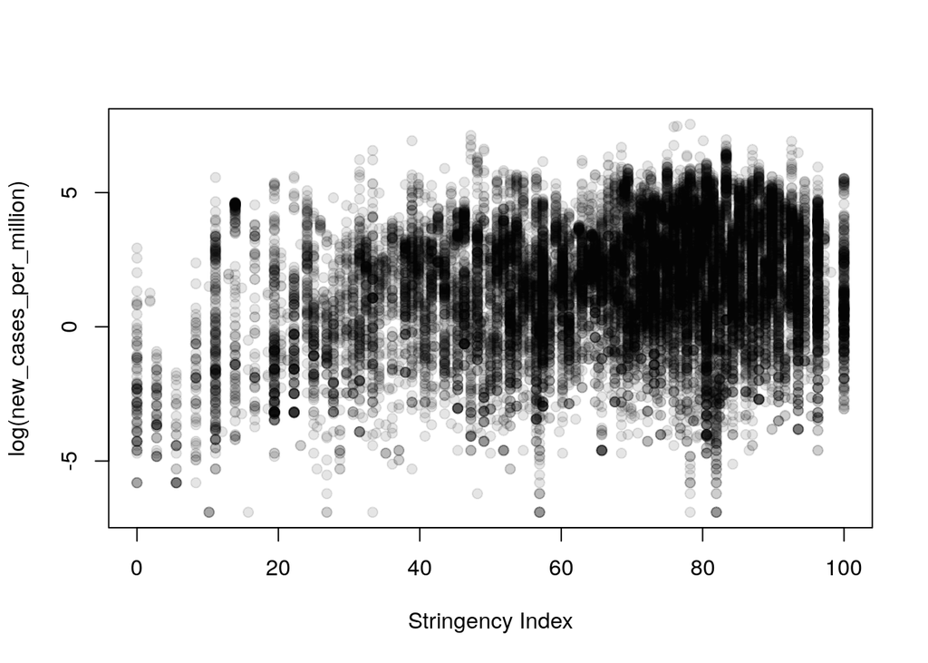

```r
plot(x = df$stringency_index, y=df$log_case, pch = 19, col = grey(0, 0.1), xlab = "Stringency Index", ylab = "log(new_cases_per_million)")
```

Modelling

```r
## Define 10 splits
set.seed(123)
labels <- rep(1:10, length.out=N)
groups <- sample(labels)
```

```r
RMSE <- function(i, formula) {
    testSet <- groups == i
    trainSet <- groups != i
    fit <- lm(formula, data.frame(x=df$stringency_index[trainSet], y=df$log_cases[trainSet]))
    pred <- predict(fit, data.frame(x=df$stringency_index[testSet]))
    ob <- df$log_cases[testSet]
    sqrt(mean((pred - ob)^2))
}
```

## Commentary:

The RMSE() function splits the data into test and training sets using a label between 1 and 10.

- Step 1: It then uses the training set to fit a model relating the number of cases per day (we use the log of new cases per million) to the stringency of measures (against COVID) based on the provided formula;
- Step 2: It generates predictions for the test set;
- Step 3: It calculates the Root Mean Square Error (RMSE) for the test set.

The following code evaluates the constant cases (per million) per day model by cross-validation using the formula $y ~ 1$.

```r
mean(sapply(1:10, RMSE, y ~ 1))
```

```
## [1] 2.248936
```

The following code evaluates a simple linear regression model using the formula $y ~ x$. We perform cross-validation by calling RMSE() for i from 1 to 10, then average the resulting the RMSE values.

```r
mean(sapply(1:10, RMSE, y ~ x))
```

```
## [1] 2.179995
```

The following code evaluates a polynomial regression model using the formula $y ~ x + I(x^2)$. We perform cross-validation by calling RMSE() for i from 1 to 10, then average the resulting the RMSE values. The polynomial regression model gives the smallest RMSE.

```r
mean(sapply(1:10, RMSE, y ~ x + I(x^2)))
```

```
## [1] 2.157435
```

A plot of the complete data shows the polynomial regression model performs better than the simple linear regression model and the overall mean of cases per day; the polynomial regression model allows for the change of increasing rate when the index hit 60.

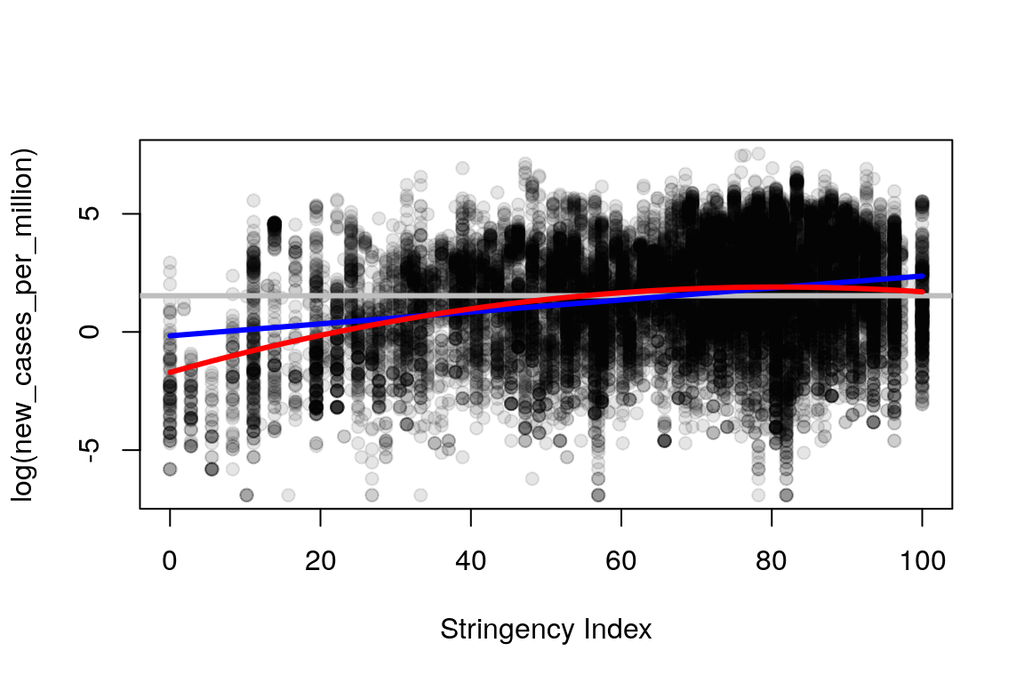

```r
PredSimple <- mean(df$log_cases)
Fit1 <- lm(log_cases ~ stringency_index, data = df)
Fit2 <- lm(log_cases ~ stringency_index + I(stringency_index^2), data = df)
o <- order(df$stringency_index)

plot(df$log_case~df$stringency_index, pch = 19, col = grey(0, 0.1), xlab = "Stringency Index", ylab = "log(new_cases_per_million)")
abline(h=PredSimple, col="grey", lwd=3)
lines(df$stringency_index[o], fitted(Fit1)[o], col="blue", lwd=3)
lines(df$stringency_index[o], fitted(Fit2)[o], col="red", lwd=3, type = "l")
```

# Conclusion

- The data consist of information for 211 locations (the last one is for the entire World), including numbers of cases of COVID per day (from the start of the year). We are interested in the relationship between the stringency of measures (against COVID) and the number of cases per day. We extracted the two interested variables from the file and ended up with 32,927 records. We found that there is an increasing trend between the log of new cases per million and the stringency index, but after the index hit 60, the number of new cases seems to be flattened out (the rate of increase slows down).
- One reason for caution is that we throw out about $1/3$ of our data which are zero values, so our estimate of the zero cases would be less reliable.
- We used 10-fold cross-validation to determine that the polynomial regression model performs better than the simple linear regression model and the overall mean of cases per day.